# Tariff exposure and county unemployment: an event study in levels

Main results. Fixed 2025 exposure interacted with calendar months

Amir Azlan, University of Illinois Urbana-Champaign

November 18, 2026

# 0. Design

The 2025 tariffs reached every county in the same months. Counties differ in **dose**, through their industry mix, and not in **timing**. A design built on event-time lags (the distributed lag in `05`, the local projections in `07`) asks the data for timing variation it does not have; `07` documents how those estimates break down. The design that fits a synchronized shock with continuous intensity is the one used by Flaaen & Pierce (2024), on which Azzimonti & Titcomb (2026) (AT2026) build: hold each county’s exposure **fixed**, and let its relationship with the outcome vary by calendar month.

$$u_{c,t}=\alpha_{c,m(t)}+\gamma_t+\sum_{s\,\notin\,2024}\Big(\beta^{IP}_s\,IP_c+\beta^{RIC}_s\,RIC_c\Big)\mathbf{1}\{t=s\}+\varepsilon_{c,t}$$

- $u_{c,t}$ is the county unemployment rate **in levels** (percent), from LAUS.
- $IP_c$ and $RIC_c$ are the county’s cumulative 2025 change in Local Import Protection and Local Rising Input Costs (built in `05` from HTS-10 customs data, the BEA use table and 2024 QCEW employment shares). They are single numbers per county.
- $\alpha_{c,m(t)}$ is a county x calendar-month fixed effect. LAUS county series are not seasonally adjusted, and seasonal patterns differ with industry mix, so each county gets its own seasonal profile. $\gamma_t$ is a date fixed effect.
- **All twelve months of 2024 are the reference period.** With county x calendar-month effects, one reference is needed per calendar month. $\beta_s$ is therefore the unemployment gap between high- and low-exposure counties in month $s$, relative to the gap in the same calendar month of 2024.
- **2023 months are placebos**: the tariffs had not happened, so $\beta_s$ should be zero.
- Standard errors are clustered by state.

Both exposure measures are divided by their 10th-90th percentile spread across counties, so every coefficient reads directly as **percentage points of unemployment for a county at the 90th percentile of exposure relative to one at the 10th**.

```r
panel_start <- as.Date("2023-01-01")   # 2023 = placebo year
ref_year    <- 2024                    # reference year (pre-tariff)
shock_start <- as.Date("2025-01-01")   # exposure = cumulative change over this window
shock_end   <- as.Date("2025-12-01")
main_month  <- as.Date("2025-04-01")   # realized tariff rates rise sharply from April 2025
base_year_qcew <- 2024
```

# 1. Data

```r
ce <- fread(file.path(proc, "county_exposure_monthly.csv.gz"), colClasses = list(character = "fips"))
ce[, date := as.Date(date)]

laus <- fread(file.path(proc, "laus_county_unemployment.csv"),
              colClasses = list(character = c("fips", "state_fips")))
laus[, date := as.Date(date)]
laus <- laus[date >= panel_start & !is.na(unemp_rate), .(fips, date, unemp_rate)]

qpath <- c(file.path(proc, sprintf("qcew_county_industry_%d.parquet", base_year_qcew)),
           file.path(proc, sprintf("qcew_county_industry_%d.csv.gz", base_year_qcew)))
qpath <- qpath[file.exists(qpath)][1]
q <- if (grepl("parquet$", qpath)) as.data.table(arrow::read_parquet(qpath)) else
  fread(qpath, colClasses = list(character = c("area_fips", "agglvl_code", "own_code", "industry_code")))
q[, `:=`(area_fips = as.character(area_fips), agglvl_code = as.character(agglvl_code),
         own_code = as.character(own_code), industry_code = as.character(industry_code))]
Nc <- q[agglvl_code == "70" & own_code == "0", .(fips = area_fips, N_c = emp_avg)]
Nc <- Nc[!is.na(N_c) & N_c > 0]

all_months <- sort(unique(laus$date))      # October 2025 is absent: LAUS has no county data
mtag <- function(d) format(d, "%Y%m")
cat(sprintf("Outcome months: %s to %s (%d months; missing: %s)\n", min(all_months), max(all_months),
            length(all_months),
            paste(format(setdiff(as.character(seq(min(all_months), max(all_months), by = "month")),
                                 as.character(all_months))), collapse = ", ")))
```

```
## Outcome months: 2023-01-01 to 2026-09-01 (44 months; missing: 2025-10-01)
```

# 2. Fixed county exposure

```r
fixed_exposure <- function(ce_dt, from = shock_start, to = shock_end)
  ce_dt[date >= from & date <= to, .(IP_fix = sum(dIP), RIC_fix = sum(dRIC)), by = fips]

ex <- fixed_exposure(ce)
qs <- c(.10, .25, .50, .75, .90, .99)
data.table(measure = c("Local IP, 2025 cumulative change", "Local RIC, 2025 cumulative change"),
           rbind(round(quantile(ex$IP_fix, qs), 3), round(quantile(ex$RIC_fix, qs), 3)))
```

| measure | 10% | 25% | 50% | 75% | 90% | 99% |
| --- | --- | --- | --- | --- | --- | --- |
| Local IP, 2025 cumulative change | 0.008 | 0.039 | 0.128 | 0.311 | 0.593 | 1.339 |
| Local RIC, 2025 cumulative change | 0.122 | 0.196 | 0.302 | 0.413 | 0.534 | 0.846 |

```r
cat(sprintf("Cross-county correlation of IP and RIC exposure: %.3f\n", cor(ex$IP_fix, ex$RIC_fix)))
```

```
## Cross-county correlation of IP and RIC exposure: 0.853
```

The correlation above matters for everything that follows. If it is high, the two channels are hard to separate and the single-channel estimates in section 5 are the safer reading.

```r
# Builds the estimation panel: outcome, scaled exposure, and one exposure x month column
# per channel and month. Scaling: exposure / (p90 - p10), so coefficients are in
# percentage points of unemployment per p10 -> p90 difference in exposure.
make_panel <- function(ex_dt) {
  e <- copy(ex_dt)
  sp_ip  <- unname(diff(quantile(e$IP_fix,  c(.10, .90))))
  sp_ric <- unname(diff(quantile(e$RIC_fix, c(.10, .90))))
  e[, `:=`(IP_s = IP_fix / sp_ip, RIC_s = RIC_fix / sp_ric)]
  D <- merge(laus, e[, .(fips, IP_fix, RIC_fix, IP_s, RIC_s)], by = "fips")
  D <- merge(D, Nc, by = "fips")
  D[, `:=`(state = substr(fips, 1, 2), cal_month = month(date), yr = year(date))]
  for (i in seq_along(all_months)) {
    d <- all_months[i]
    set(D, j = paste0("IP_",  mtag(d)), value = D$IP_s  * (D$date == d))
    set(D, j = paste0("RIC_", mtag(d)), value = D$RIC_s * (D$date == d))
  }
  D[]
}
D <- make_panel(ex)
cat(sprintf("Panel: %s county-months, %s counties, %d states\n", format(nrow(D), big.mark = ","),
            format(uniqueN(D$fips), big.mark = ","), uniqueN(D$state)))
```

```
## Panel: 138,292 county-months, 3,143 counties, 51 states
```

# 3. The raw data first

Before any regression: mean unemployment for the most- and least-exposed quarter of counties (by IP exposure), and the gap between them. The regression in section 4 is a disciplined version of the bottom panel.

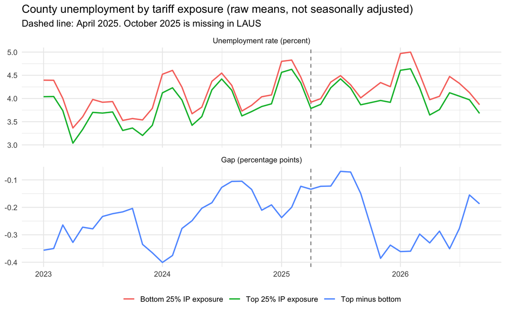

```r
cut_q <- quantile(ex$IP_fix, c(.25, .75))
grp <- ex[, .(fips, g = fifelse(IP_fix >= cut_q[2], "Top 25% IP exposure",
                         fifelse(IP_fix <= cut_q[1], "Bottom 25% IP exposure", NA_character_)))][!is.na(g)]
raw <- merge(D[, .(fips, date, unemp_rate)], grp, by = "fips")[, .(u = mean(unemp_rate)), by = .(g, date)]
gap <- dcast(raw, date ~ g, value.var = "u")
gap[, u := `Top 25% IP exposure` - `Bottom 25% IP exposure`]
rawp <- rbind(raw[, .(date, series = g, u, panel = "Unemployment rate (percent)")],
              gap[, .(date, series = "Top minus bottom", u, panel = "Gap (percentage points)")])
rawp[, panel := factor(panel, levels = c("Unemployment rate (percent)", "Gap (percentage points)"))]

ggplot(rawp, aes(date, u, colour = series)) +
  geom_vline(xintercept = main_month, linetype = "dashed", colour = "grey50") +
  geom_line(linewidth = 0.8) + facet_wrap(~panel, ncol = 1, scales = "free_y") +
  labs(title = "County unemployment by tariff exposure (raw means, not seasonally adjusted)",
       subtitle = "Dashed line: April 2025. October 2025 is missing in LAUS",
       x = NULL, y = NULL, colour = NULL) +
  theme_minimal(base_size = 12) + theme(legend.position = "bottom")
```

```r
ggsave(file.path(figd, "main_fig_raw_groups.png"), width = 9, height = 5.6, dpi = 150)
```

# 4. Event study

```r
ev_months <- all_months[year(all_months) != ref_year]

fit_es <- function(data, months = ev_months, which = c("IP", "RIC"),
                   fe = "fips^cal_month + date", wt = NULL, y = "unemp_rate") {
  tt <- unlist(lapply(which, function(p) paste0(p, "_", mtag(months))))
  f <- feols(as.formula(paste(y, "~", paste(tt, collapse = " + "), "|", fe)),
             data = data, cluster = ~state, weights = wt)
  dropped <- setdiff(tt, names(coef(f)))
  if (length(dropped)) warning("Collinear terms dropped: ", paste(dropped, collapse = ", "), call. = FALSE)
  f
}

# monthly coefficient path, with the reference months added back as zeros
coef_path <- function(fit, prefix, months = ev_months, ref = all_months[year(all_months) == ref_year]) {
  nm <- paste0(prefix, "_", mtag(months)); ok <- nm %in% names(coef(fit))
  p <- data.table(date = months[ok], est = unname(coef(fit)[nm[ok]]), se = unname(se(fit)[nm[ok]]))
  p <- rbind(p, data.table(date = ref, est = 0, se = 0))
  setorder(p, date)
  p[, `:=`(lo = est - 1.96 * se, hi = est + 1.96 * se)][]
}

# average of the monthly coefficients over a window, with its standard error
avg_effect <- function(fit, prefix, months) {
  nm <- paste0(prefix, "_", mtag(months)); nm <- nm[nm %in% names(coef(fit))]
  if (!length(nm)) return(NULL)
  a <- rep(1 / length(nm), length(nm))
  b <- coef(fit)[nm]; V <- vcov(fit)[nm, nm, drop = FALSE]
  data.table(est = sum(a * b), se = sqrt(drop(t(a) %*% V %*% a)), n_months = length(nm))
}

# joint test that every coefficient in a window is zero
wald_p <- function(fit, prefix, months) {
  nm <- paste0(prefix, "_", mtag(months)); nm <- nm[nm %in% names(coef(fit))]
  if (!length(nm)) return(NA_real_)
  b <- coef(fit)[nm]; V <- vcov(fit)[nm, nm, drop = FALSE]
  W <- tryCatch(drop(t(b) %*% solve(V) %*% b), error = function(e) NA_real_)
  pchisq(W, length(nm), lower.tail = FALSE)
}

yr <- year(all_months)
windows <- list(
  "Placebo: 2023"   = all_months[yr == 2023],
  "2025 Jan-Mar"    = all_months[yr == 2025 & month(all_months) <= 3],
  "2025 Apr-Dec"    = all_months[yr == 2025 & month(all_months) >= 4],
  "2026 Jan onward" = all_months[yr == 2026])

summarise_fit <- function(fit, label) {
  rbindlist(lapply(c("IP", "RIC"), function(p) {
    rbindlist(lapply(names(windows), function(w) {
      r <- avg_effect(fit, p, windows[[w]])
      if (is.null(r)) return(NULL)
      r[, `:=`(spec = label, channel = p, window = w)]
      r
    }))
  }))
}
```

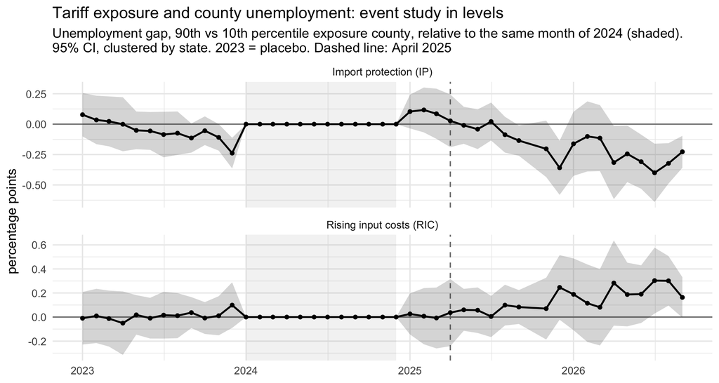

```r
fit_main <- fit_es(D)

paths <- rbind(coef_path(fit_main, "IP")[,  exposure := "Import protection (IP)"],
               coef_path(fit_main, "RIC")[, exposure := "Rising input costs (RIC)"])

ggplot(paths, aes(date, est)) +
  annotate("rect", xmin = as.Date(sprintf("%d-01-01", ref_year)), xmax = as.Date(sprintf("%d-12-01", ref_year)),
           ymin = -Inf, ymax = Inf, alpha = 0.08) +
  geom_hline(yintercept = 0, colour = "grey50") +
  geom_vline(xintercept = main_month, linetype = "dashed", colour = "grey50") +
  geom_ribbon(aes(ymin = lo, ymax = hi), alpha = 0.2) +
  geom_line(linewidth = 0.8) + geom_point(size = 1.3) +
  facet_wrap(~exposure, ncol = 1, scales = "free_y") +
  labs(title = "Tariff exposure and county unemployment: event study in levels",
       subtitle = paste0("Unemployment gap, 90th vs 10th percentile exposure county, relative to the same month of ",
                         ref_year, " (shaded).\n95% CI, clustered by state. 2023 = placebo. Dashed line: April 2025"),
       x = NULL, y = "percentage points") +
  theme_minimal(base_size = 12)
```

```r
ggsave(file.path(figd, "main_fig_event_study.png"), width = 9, height = 6.2, dpi = 150)
```

```r
main_tab <- summarise_fit(fit_main, "Baseline")
main_tab[, `:=`(t = est / se, lo = est - 1.96 * se, hi = est + 1.96 * se)]
main_tab[, .(channel, window, months = n_months, `effect (pp)` = round(est, 3), se = round(se, 3),
             t = round(t, 2), `95% CI` = sprintf("[%.3f, %.3f]", lo, hi))]
```

| channel | window | months | effect (pp) | se | t | 95% CI |
| --- | --- | --- | --- | --- | --- | --- |
| IP | Placebo: 2023 | 12 | -0.054 | 0.063 | -0.86 | [-0.177, 0.069] |
| IP | 2025 Jan-Mar | 3 | 0.102 | 0.086 | 1.18 | [-0.067, 0.271] |
| IP | 2025 Apr-Dec | 8 | -0.098 | 0.071 | -1.38 | [-0.238, 0.041] |
| IP | 2026 Jan onward | 9 | -0.244 | 0.106 | -2.30 | [-0.452, -0.036] |
| RIC | Placebo: 2023 | 12 | 0.009 | 0.071 | 0.13 | [-0.131, 0.149] |
| RIC | 2025 Jan-Mar | 3 | 0.009 | 0.105 | 0.08 | [-0.197, 0.214] |
| RIC | 2025 Apr-Dec | 8 | 0.082 | 0.076 | 1.09 | [-0.066, 0.230] |
| RIC | 2026 Jan onward | 9 | 0.202 | 0.121 | 1.67 | [-0.035, 0.438] |

Each row is the average of the monthly coefficients in that window: the unemployment-rate difference, in percentage points, between a 90th- and a 10th-percentile exposure county, relative to 2024.

## 4.1 Pre-trends

The 2023 coefficients are the test of the design. Two versions: the average 2023 coefficient (the “Placebo: 2023” rows above) and a joint test that all twelve are zero. The joint test uses 12 restrictions with about 50 state clusters and tends to over-reject, so read it together with the average and with the figure.

```r
data.table(channel = c("IP", "RIC"),
           `joint p-value, all 2023 months = 0` =
             round(c(wald_p(fit_main, "IP", windows[[1]]), wald_p(fit_main, "RIC", windows[[1]])), 3),
           `average 2023 coefficient (pp)` =
             round(c(avg_effect(fit_main, "IP", windows[[1]])$est, avg_effect(fit_main, "RIC", windows[[1]])$est), 3),
           `t` = round(c(avg_effect(fit_main, "IP", windows[[1]])[, est / se],
                         avg_effect(fit_main, "RIC", windows[[1]])[, est / se]), 2))
```

| channel | joint p-value, all 2023 months = 0 | average 2023 coefficient (pp) | t |
| --- | --- | --- | --- |
| IP | 0.00 | -0.054 | -0.86 |
| RIC | 0.73 | 0.009 | 0.13 |

## 4.2 What could this design have detected?

A null is informative only if the design could have found a plausible effect. The smallest effect detectable with 80% power at the 5% level is about 2.8 standard errors.

```r
mde <- main_tab[window %in% c("2025 Apr-Dec", "2026 Jan onward"),
                .(channel, window, `estimate (pp)` = round(est, 3), se = round(se, 3),
                  `smallest detectable effect (pp)` = round(2.8 * se, 3))]
mde
```

| channel | window | estimate (pp) | se | smallest detectable effect (pp) |
| --- | --- | --- | --- | --- |
| IP | 2025 Apr-Dec | -0.098 | 0.071 | 0.199 |
| IP | 2026 Jan onward | -0.244 | 0.106 | 0.297 |
| RIC | 2025 Apr-Dec | 0.082 | 0.076 | 0.212 |
| RIC | 2026 Jan onward | 0.202 | 0.121 | 0.338 |

```r
cat(sprintf("For scale: mean county unemployment rate in %d was %.2f percent (sd across counties %.2f).\n",
            ref_year, D[yr == ref_year, mean(unemp_rate)],
            D[yr == ref_year, .(u = mean(unemp_rate)), by = fips][, sd(u)]))
```

```
## For scale: mean county unemployment rate in 2024 was 3.96 percent (sd across counties 1.26).
```

## 4.3 Positive control

Add a known effect to the outcome (`b` percentage points per unit of scaled IP exposure from April 2025 on) and re-estimate. Because exposure is a fixed county characteristic, the design recovers it exactly; `07` shows that the local-projection design does not have this property. A recovered value different from `b` would indicate a coding error.

```r
base_post <- avg_effect(fit_main, "IP", windows[["2025 Apr-Dec"]])$est
pc <- rbindlist(lapply(c(0.1, 0.5), function(b) {
  d <- copy(D)
  d[, y_sim := unemp_rate + b * IP_s * (date >= main_month)]
  f <- fit_es(d, y = "y_sim")
  data.table(injected = b, recovered = avg_effect(f, "IP", windows[["2025 Apr-Dec"]])$est - base_post)
}))
pc[, recovered := round(recovered, 6)][]
```

| injected | recovered |
| --- | --- |
| 0.1 | 0.1 |
| 0.5 | 0.5 |

# 5. Robustness

Each row changes one thing relative to the baseline.

```r
specs <- list()
specs[["Baseline"]] <- fit_main

# (a) one channel at a time: IP and RIC are correlated across counties
specs[["IP only"]]  <- fit_es(D, which = "IP")
specs[["RIC only"]] <- fit_es(D, which = "RIC")

# (b) no county-specific seasonality: county + date FE, December of the reference year as base
base_m <- as.Date(sprintf("%d-12-01", ref_year))
specs[["County + date FE, base Dec 2024"]] <-
  fit_es(D, months = all_months[all_months != base_m], fe = "fips + date")

# (c) weight counties by 2024 employment
specs[["Employment-weighted"]] <- fit_es(D, wt = ~N_c)

# (d) drop counties in the top 1% of IP exposure (AT2026 Table 5, columns 3-4)
keep <- ex[IP_fix < quantile(IP_fix, 0.99), fips]
specs[["Trim top 1% IP exposure"]] <- fit_es(D[fips %in% keep])

# (e) exposure measured to the October 2025 peak in realized tariff rates
specs[["Exposure through Oct 2025"]] <-
  fit_es(make_panel(fixed_exposure(ce, to = as.Date("2025-10-01"))))
```

```r
# (f) QCEW suppression: impute suppressed manufacturing cells instead of treating them as zero
ind_path <- file.path(proc, "industry_exposure_monthly.csv.gz")
if (file.exists(ind_path)) {
  MFG3 <- setdiff(as.character(311:339), c("317", "318", "319", "328", "329", "338"))
  disc <- q[agglvl_code == "75" & own_code == "5" & industry_code %in% MFG3,
            .(fips = area_fips, naics3 = industry_code, emp = emp_avg)]
  sec  <- q[agglvl_code == "74" & own_code == "5" & industry_code == "31-33",
            .(fips = area_fips, sector_emp = emp_avg)]
  natl <- disc[!is.na(emp), .(natl_emp = sum(emp)), by = naics3][, w := natl_emp / sum(natl_emp)]
  imp <- merge(disc, sec, by = "fips")
  imp <- merge(imp, natl[, .(naics3, w)], by = "naics3")
  imp[, disclosed_sum := sum(emp, na.rm = TRUE), by = fips]
  # if the county's whole sector 31-33 total is suppressed there is nothing to impute from
  imp[, gap := fifelse(is.na(sector_emp), 0, pmax(sector_emp - disclosed_sum, 0))]
  imp[, w_supp := fifelse(is.na(emp), w, 0)]
  imp[, w_supp := w_supp / sum(w_supp), by = fips]
  imp[, emp_imputed := fifelse(is.na(emp), fifelse(is.finite(w_supp), gap * w_supp, 0), emp)]
  imp[is.na(emp_imputed), emp_imputed := 0]
  shr_other <- q[agglvl_code == "75" & own_code == "5" & !industry_code %in% MFG3,
                 .(fips = area_fips, naics3 = industry_code, emp = fifelse(is.na(emp_avg), 0, emp_avg))]
  shr_imp <- rbind(imp[, .(fips, naics3, emp = emp_imputed)], shr_other)
  shr_imp <- merge(shr_imp, Nc, by = "fips")[, share := emp / N_c]
  ind_exp <- fread(ind_path, colClasses = list(character = c("naics3", "bea")))
  ind_exp[, date := as.Date(date)]
  ce_imp <- merge(shr_imp[, .(fips, naics3, share)], ind_exp[, .(naics3, date, dIP, dRIC)],
                  by = "naics3", allow.cartesian = TRUE)
  ce_imp <- ce_imp[, .(dIP = sum(share * dIP), dRIC = sum(share * dRIC)), by = .(fips, date)]
  specs[["Suppressed QCEW cells imputed"]] <- fit_es(make_panel(fixed_exposure(ce_imp)))
} else {
  cat("industry_exposure_monthly.csv.gz not found: re-knit 05 to enable the suppression check.\n")
}
```

```r
rob <- rbindlist(lapply(names(specs), function(s) summarise_fit(specs[[s]], s)))
rob[, t := est / se]
rob[, cell := sprintf("%.3f (%.3f)%s", est, se, fifelse(abs(t) > 1.96, "*", ""))]
rob[, `:=`(spec = factor(spec, levels = names(specs)), window = factor(window, levels = names(windows)))]
rob_wide <- dcast(rob, spec + channel ~ window, value.var = "cell")
pre <- rbindlist(lapply(names(specs), function(s) rbindlist(lapply(c("IP", "RIC"), function(p) {
  pv <- wald_p(specs[[s]], p, windows[[1]])
  if (is.na(pv)) NULL else data.table(spec = s, channel = p, `pre-trend joint p` = round(pv, 3))
}))))
pre[, spec := factor(spec, levels = names(specs))]
rob_wide <- merge(rob_wide, pre, by = c("spec", "channel"), all.x = TRUE)
setorder(rob_wide, channel, spec)
rob_wide
```

| spec | channel | Placebo: 2023 | 2025 Jan-Mar | 2025 Apr-Dec | 2026 Jan onward | pre-trend joint p |
| --- | --- | --- | --- | --- | --- | --- |
| Baseline | IP | -0.054 (0.063) | 0.102 (0.086) | -0.098 (0.071) | -0.244 (0.106)* | 0.000 |
| IP only | IP | -0.047 (0.035) | 0.108 (0.067) | -0.040 (0.044) | -0.102 (0.067) | 0.014 |
| County + date FE, base Dec 2024 | IP | -0.147 (0.089) | -0.128 (0.076) | -0.137 (0.085) | -0.334 (0.106)* | 0.000 |
| Employment-weighted | IP | -0.080 (0.094) | 0.123 (0.125) | -0.101 (0.159) | -0.494 (0.299) | 0.002 |
| Trim top 1% IP exposure | IP | -0.105 (0.081) | 0.190 (0.104) | -0.092 (0.082) | -0.267 (0.132)* | 0.193 |
| Exposure through Oct 2025 | IP | -0.049 (0.061) | 0.100 (0.084) | -0.096 (0.069) | -0.238 (0.104)* | 0.000 |
| Suppressed QCEW cells imputed | IP | -0.043 (0.089) | 0.092 (0.117) | -0.153 (0.103) | -0.321 (0.152)* | 0.376 |
| Baseline | RIC | 0.009 (0.071) | 0.009 (0.105) | 0.082 (0.076) | 0.202 (0.121) | 0.730 |
| RIC only | RIC | -0.046 (0.040) | 0.114 (0.081) | -0.019 (0.051) | -0.051 (0.085) | 0.727 |
| County + date FE, base Dec 2024 | RIC | 0.063 (0.111) | 0.127 (0.080) | 0.100 (0.099) | 0.237 (0.125) | 0.000 |

[output cut: 4 more lines]

Cells are the average monthly coefficient in the window with its standard error; `*` marks |t| > 1.96. Units are percentage points of unemployment per 10th-to-90th percentile difference in exposure (each exposure definition scaled by its own spread).

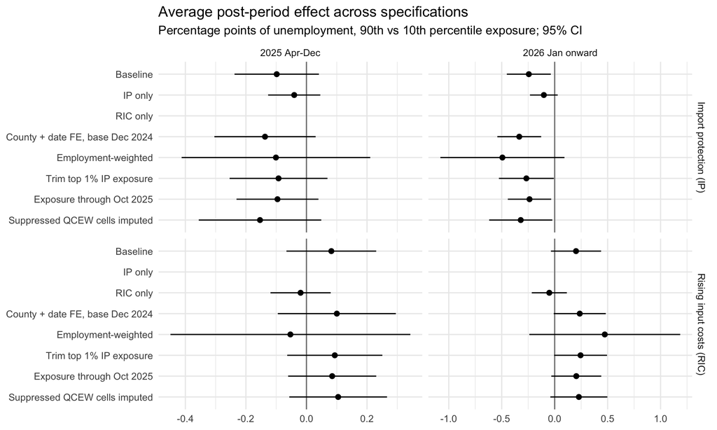

```r
rp <- rob[window %in% c("2025 Apr-Dec", "2026 Jan onward")]
rp[, `:=`(lo = est - 1.96 * se, hi = est + 1.96 * se,
          exposure = fifelse(channel == "IP", "Import protection (IP)", "Rising input costs (RIC)"))]
ggplot(rp, aes(est, spec)) +
  geom_vline(xintercept = 0, colour = "grey50") +
  geom_pointrange(aes(xmin = lo, xmax = hi), size = 0.3) +
  facet_grid(exposure ~ window, scales = "free_x") +
  scale_y_discrete(limits = rev) +
  labs(title = "Average post-period effect across specifications",
       subtitle = "Percentage points of unemployment, 90th vs 10th percentile exposure; 95% CI",
       x = NULL, y = NULL) +
  theme_minimal(base_size = 11)
```

```r
ggsave(file.path(figd, "main_fig_robustness.png"), width = 9, height = 5.4, dpi = 150)
```

# 6. Saved results

```r
out_main <- main_tab[, .(channel, window, months = n_months, effect_pp = round(est, 4), se = round(se, 4),
                         t = round(t, 2), ci_low = round(lo, 4), ci_high = round(hi, 4))]
fwrite(out_main, file.path(outd, "main_results.csv"))
fwrite(rob[, .(spec, channel, window, effect_pp = round(est, 4), se = round(se, 4), t = round(t, 2))],
       file.path(outd, "main_results_robustness.csv"))
fwrite(rbind(paths[, .(exposure, date, est, se)]), file.path(outd, "main_event_study_coefficients.csv"))

md <- c("# Main results",
        "",
        sprintf("Generated by `scripts/08_event_study_levels.Rmd` on %s.", format(Sys.Date(), "%B %d, %Y")),
        "",
        "Unemployment-rate difference (percentage points) between a county at the 90th and one at the",
        sprintf("10th percentile of exposure, relative to the same calendar months of %d. Standard errors", ref_year),
        "clustered by state. `Placebo: 2023` should be zero if the design is valid.",
        "",
        "## Baseline", "",
        knitr::kable(out_main, format = "pipe"),
        "",
        "## Across specifications", "",
        "Average coefficient (standard error); `*` marks |t| > 1.96.", "",
        knitr::kable(rob_wide, format = "pipe"))
writeLines(md, file.path(outd, "results_summary.md"))
cat("Wrote output/main_results.csv, output/main_results_robustness.csv,",
    "output/main_event_study_coefficients.csv, output/results_summary.md\n")
```

```
## Wrote output/main_results.csv, output/main_results_robustness.csv, output/main_event_study_coefficients.csv, output/results_summary.md
```

# 7. Reading the results, and limits

**How to read them**

- The 2023 placebo rows and the pre-trend p-values come first. If high- and low-exposure counties were already diverging between 2023 and 2024, the post-period coefficients do not identify a tariff effect.
- The `2025 Apr-Dec` and `2026 Jan onward` rows are the estimates of interest. Section 4.2 gives the smallest effect this design could have detected; an insignificant estimate with a small detectable effect is evidence of a small effect, and one with a large detectable effect is not.
- If IP-only and RIC-only estimates differ sharply from the joint ones, the two channels are not separately identified and the single-channel versions should be read as the effect of tariff exposure broadly.

**Limits**

- **One shock, one cross-section.** Identification comes from industry composition. Anything else that hit manufacturing-heavy counties differently in 2025 than in 2024 is attributed to tariffs.
- **Realized tariffs are outcomes of firm behaviour** (front-loading, sourcing shifts, exemption use). Exposure built from statutory rates would be a useful instrument.
- **Exposure is fixed at its 2025 change.** Realized tariff rates fell in early 2026 in the customs data, so the 2026 coefficients mix the lagged effect of 2025 with a partial reversal.
- **Shift-share inference.** State clustering does not address correlation across counties with similar industry mixes (Adao, Kolesar & Morales 2019).
- **QCEW suppression** hides about half of manufacturing employment at NAICS-3 in the median county; row (f) of the robustness table addresses it for manufacturing only.
- **LAUS** county estimates are model-based, October 2025 is missing, and 2026 values are preliminary.
- **Not captured:** retaliation on exports and general-equilibrium effects, as in AT2026.